# Lecture 6: Effects at quantiles and quantile regression

Economics 527: Econometric Methods

Vadim Marmer, UBC

# Effects at the mean and at quantiles

## Effect at the mean

- One regressor:
  $$Y_i = \beta_0 + \beta_1 X_i + U_i, \qquad \mathrm{E}\left[U_i \mid X_i\right] = 0$$
- Effect for the “average” individual, with $U_i = 0$:
  $$\beta_1 = \frac{\partial(\beta_0 + \beta_1 X_i)}{\partial X_i}$$
- Under normality:
  $$\begin{aligned}
  U_i \mid X_i &\sim N(0,\ \sigma^2) \\
  \Longrightarrow\quad \mathrm{E}\left[Y_i \mid X_i\right] &= \beta_0 + \beta_1 X_i
  \end{aligned}$$
- Average effect: $\beta_1$.

## Conditional quantile $q^Y_\tau(X_i)$

- $z_\tau$ for $Z \sim N(0,1)$:
  $$\mathrm{P}(Z \le z_\tau) = \tau, \qquad \tau \in (0,1)$$
- **Definition.** $q^Y_\tau(X_i)$, the $\tau$-th quantile of $Y_i$ given $X_i$:
  $$\mathrm{P}\big(Y_i \le q^Y_\tau(X_i) \mid X_i\big) = \tau$$
- **Claim.**
  $$q^Y_\tau(X_i) = \beta_0 + \beta_1 X_i + q^U_\tau(X_i)$$
- **Claim.** Under $U_i \mid X_i \sim N(0,\ \sigma^2)$:
  $$q^U_\tau(X_i) = \sigma z_\tau$$

## Verification

- Check that $\beta_0 + \beta_1 X_i + \sigma z_\tau$ is the $\tau$-th quantile of $Y_i$ given $X_i$:
  $$\begin{aligned}
  & \mathrm{P}\Big(Y_i \le \beta_0 + \beta_1 X_i + \underbrace{\sigma z_\tau}_{q^U_\tau(X_i)} \mid X_i\Big) \\
  &= \mathrm{P}\big({\color{red} \beta_0 + \beta_1 X_i} + U_i \le {\color{red} \beta_0 + \beta_1 X_i} + \sigma z_\tau \mid X_i\big) \\
  &= \mathrm{P}\big(U_i \le \sigma z_\tau \mid X_i\big) \\
  &= \mathrm{P}\Big(\underbrace{\frac{U_i}{\sigma}}_{N(0,1)} \le z_\tau \mid X_i\Big) \\
  &= \tau
  \end{aligned}$$

## Same effect at every quantile

- Therefore:
  $$\begin{aligned}
  &\boxed{\ q^Y_\tau(X_i) = \beta_0 + \beta_1 X_i + \sigma z_\tau\ } \\
  &= (\beta_0 + \sigma z_\tau) + \beta_1 X_i
  \end{aligned}$$
- Effect at the $\tau$-th quantile:
  $$\begin{aligned}
  \frac{\partial q^Y_\tau(X_i)}{\partial X_i} &= \frac{\partial\big[\beta_0 + \beta_1 X_i + \overbrace{\sigma z_\tau}^{\text{const.}}\big]}{\partial X_i} \\
  &= \beta_1
  \end{aligned}$$
- Same effect $\beta_1$ at every quantile and at the mean.
- For example, $z_{0.05} \approx -1.64$:
  $$q^Y_{0.05}(X_i) \approx \beta_0 + \beta_1 X_i - 1.64\,\sigma$$

## Equal spread and parallel quantile lines

- Densities of $Y_i$ given $X_i = x$ on $\beta_0 + \beta_1 x$, and $q^Y_{0.75}(x)$, $q^Y_{0.25}(x)$:

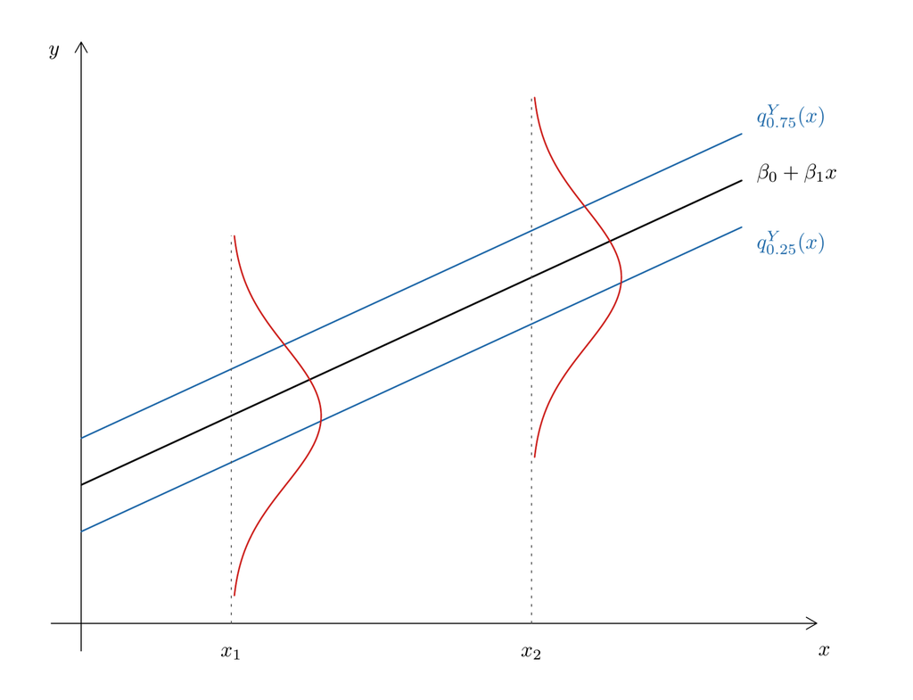

## Heteroskedastic normal model

- Suppose:
  $$\begin{aligned}
  U_i \mid X_i &\sim N\big(0,\ \underbrace{\sigma^2(X_i)}_{\text{not const.}}\big) \\
  \Longrightarrow\quad & \boxed{\ q^Y_\tau(X_i) = \beta_0 + \beta_1 X_i + \sigma(X_i)\, z_\tau\ }
  \end{aligned}$$
- Exponential scale:
  $$\sigma(X_i) = e^{\gamma_0 + \gamma_1 X_i}$$
- Effect at the $\tau$-th quantile:
  $$\begin{aligned}
  \frac{\partial q^Y_\tau(X_i)}{\partial X_i} &= \frac{\partial\big[\beta_0 + \beta_1 X_i + \sigma(X_i)\, z_\tau\big]}{\partial X_i} \\
  &= \beta_1 + z_\tau\, \frac{\partial \sigma(X_i)}{\partial X_i} \\
  &= \beta_1 + z_\tau\, \frac{\partial e^{\gamma_0 + \gamma_1 X_i}}{\partial X_i} \\
  &= \beta_1 + z_\tau\, \overbrace{\underbrace{\sigma(X_i)}_{e^{\gamma_0 + \gamma_1 X_i}}\, \gamma_1}^{>\,0 \ \text{ if } \gamma_1 > 0}
  \end{aligned}$$

## Effects above and below the median

- Sign of $z_\tau$:
  $$\begin{aligned}
  z_\tau &> 0 \quad \text{if } \tau > 0.5 \\
  z_{0.5} &= 0 \\
  z_\tau &< 0 \quad \text{if } \tau < 0.5 \\
  z_\tau &\to -\infty \quad \text{as } \tau \to 0
  \end{aligned}$$
- Suppose $\gamma_1 > 0$:
  $$\frac{\partial q^Y_\tau(X_i)}{\partial X_i} = \beta_1 + z_\tau\, \sigma(X_i)\, \gamma_1
  \ \begin{cases}
  > \beta_1 & \text{if } \tau > 0.5 \\
  = \beta_1 & \text{if } \tau = 0.5 \\
  < \beta_1 & \text{if } \tau < 0.5
  \end{cases}$$
- At the median:
  $$\begin{aligned}
  q^Y_{0.5}(X_i) &= \beta_0 + \beta_1 X_i \\
  &= \mathrm{E}\left[Y_i \mid X_i\right]
  \end{aligned}$$

## Where heterogeneity comes from

- Given $X_i$, a distribution of $U_i$:
  $$\mathrm{E}\left[U_i \mid X_i\right] = 0, \qquad \text{but } U_i \text{ and } X_i \text{ not independent}$$
- Scale times a standard normal:
  $$\begin{aligned}
  U_i &= \sigma(X_i)\, \varepsilon_i, \qquad \varepsilon_i \mid X_i \sim N(0,1) \\
  \Longrightarrow\quad q^Y_\tau(X_i) &= \beta_0 + \beta_1 X_i + \sigma(X_i)\, z_\tau
  \end{aligned}$$
- Individual at the $\tau$-th quantile of $Y_i$ given $X_i$:
  $$\begin{aligned}
  \varepsilon_i &= z_\tau \\
  \Longleftrightarrow\quad Y_i &= \beta_0 + \beta_1 X_i + \sigma(X_i)\, z_\tau \\
  &= q^Y_\tau(X_i)
  \end{aligned}$$

## Widening densities and fanning quantile curves

- Densities on $\beta_0 + \beta_1 x$, then $q^Y_{0.8}(x)$ and $q^Y_{0.2}(x)$:

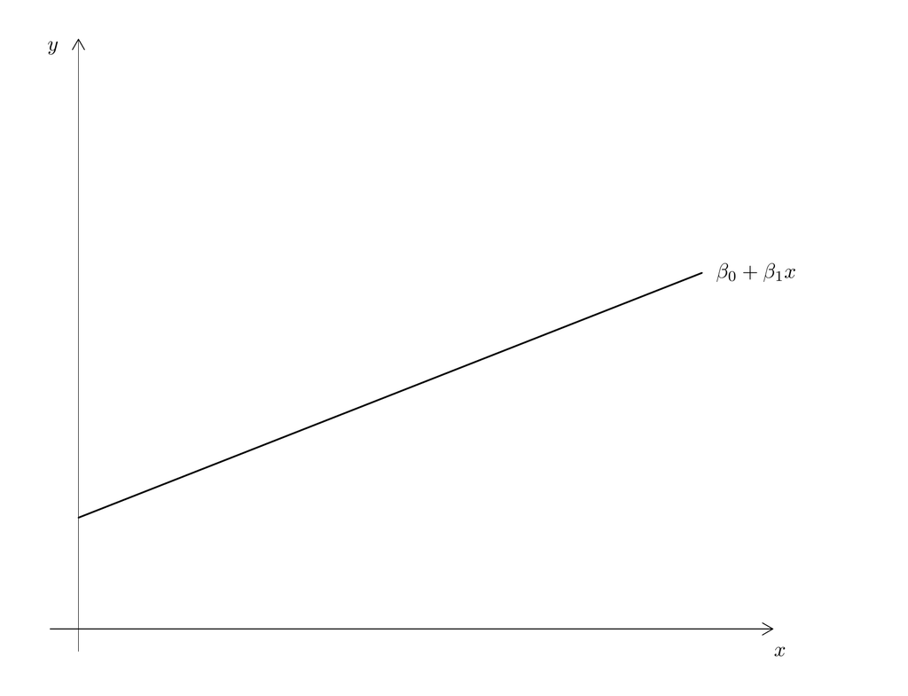

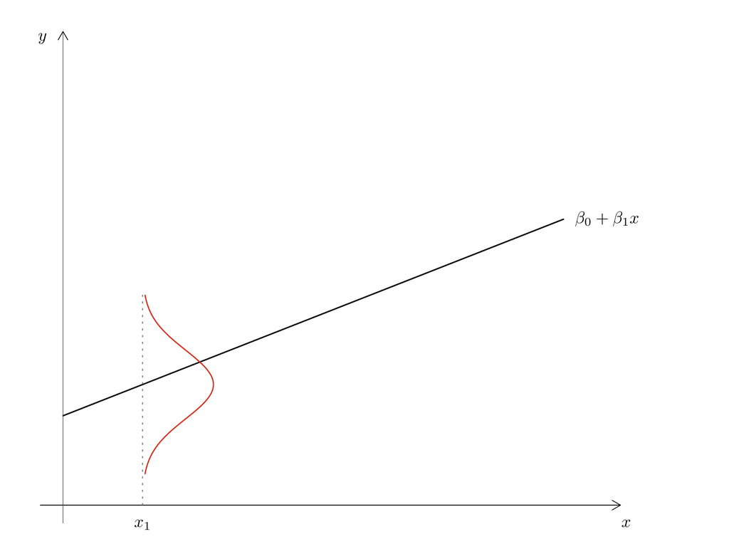

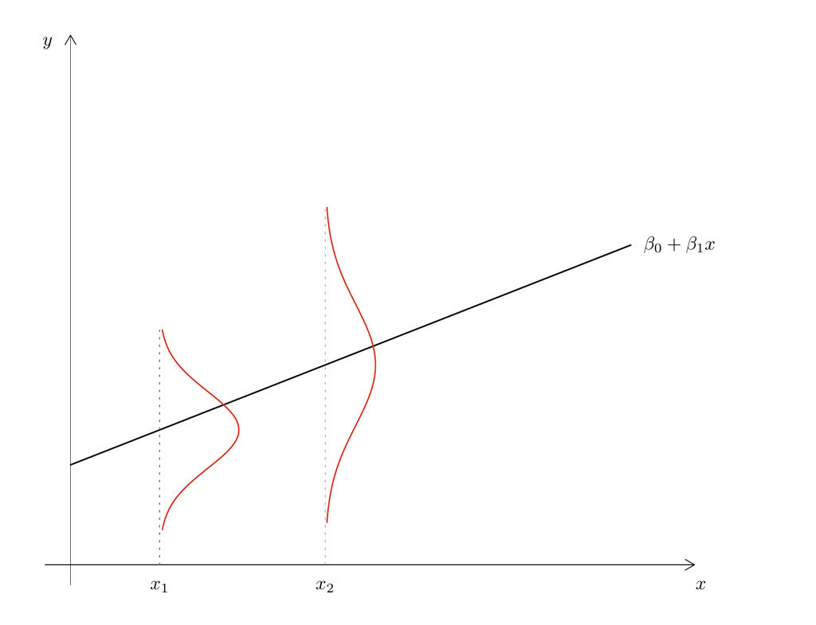

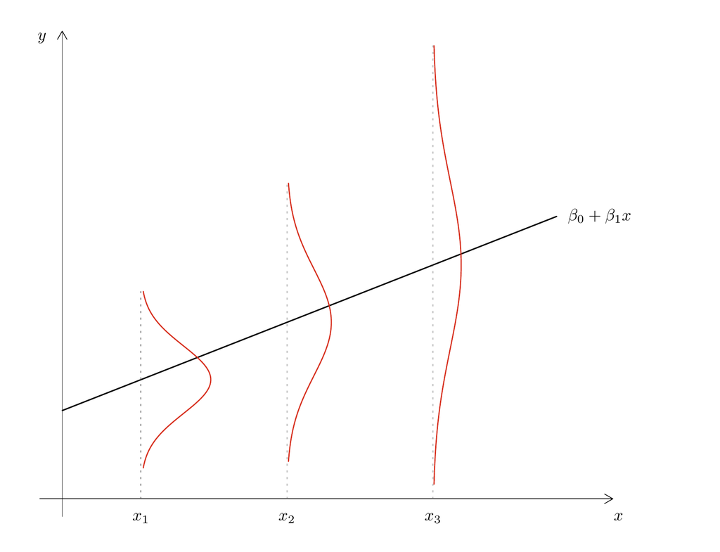

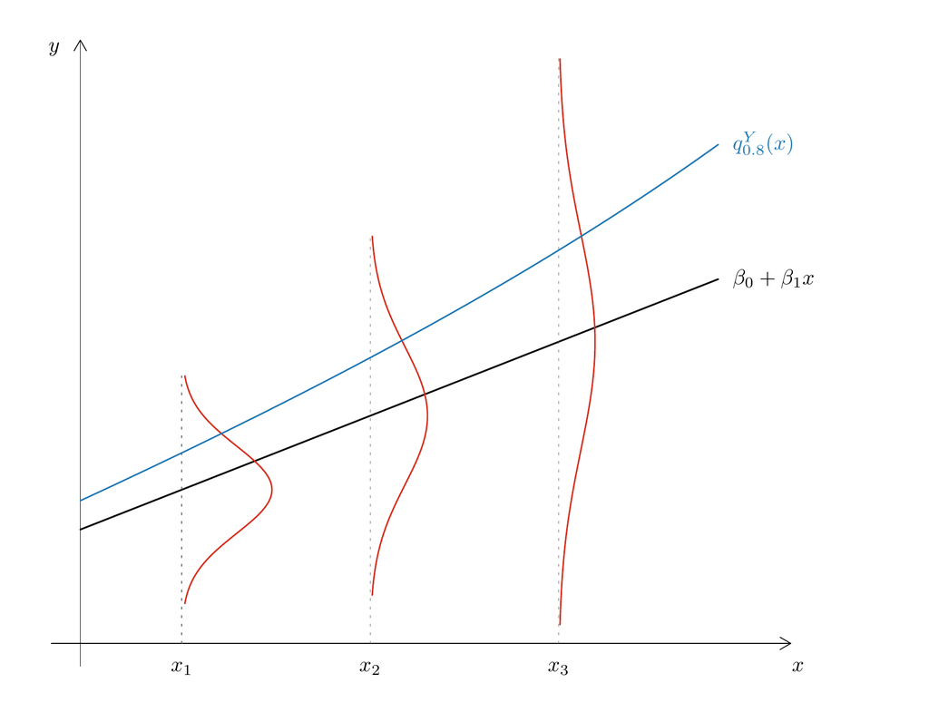

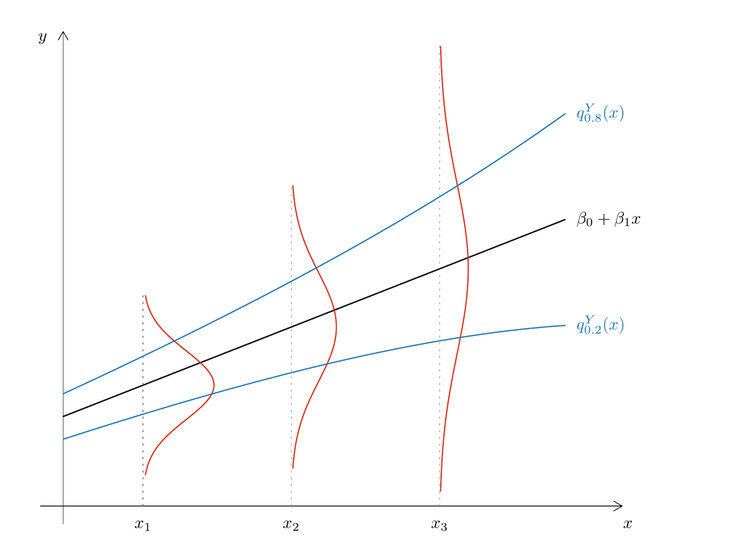

# Quantile regression

## Quantile regression without normality

- Explain $q^Y_\tau(X_i)$ instead of $\mathrm{E}\left[Y_i \mid X_i\right]$.
- No model for $\sigma(X_i)$.
- Mean as an optimizer:
  $$\underbrace{\mathrm{E}\left[Y_i\right]}_{\mu} = \underset{c \in \mathbb{R}}{\arg\min}\ \mathrm{E}\left[(\underset{1\times 1}{Y_i} - \underset{1\times 1}{c})^2\right]$$
- **Definition.** Check function, $\tau \in (0,1)$:
  $$\rho_\tau(u) = u\, \big(\tau - \mathbf{1}(u < 0)\big)$$
- Two branches:
  $$\begin{aligned}
  u < 0 \quad &\Longrightarrow\quad \rho_\tau(u) = (\tau - 1)\, u \\
  u > 0 \quad &\Longrightarrow\quad \rho_\tau(u) = \tau\, u
  \end{aligned}$$
- **Definition.** $q^Y_\tau$, the $\tau$-th quantile of $Y_i$:
  $$\mathrm{P}\big(Y_i \le q^Y_\tau\big) = \tau$$
- Quantile as an optimizer:
  $$q^Y_\tau = \underset{c \in \mathbb{R}}{\arg\min}\ \mathrm{E}\left[\rho_\tau(Y_i - c)\right]$$

## Median: $\tau = 0.5$

- Check function:
  $$\begin{aligned}
  \rho_{0.5}(u) &= u\, \big(0.5 - \mathbf{1}(u < 0)\big) \\
  &= \begin{cases} -\tfrac12\, u & \text{if } u < 0 \\ \tfrac12\, u & \text{if } u > 0 \end{cases} \\
  &= \tfrac12\, |u|
  \end{aligned}$$
- Median as an optimizer:
  $$\begin{aligned}
  q^Y_{0.5} &= \underset{c \in \mathbb{R}}{\arg\min}\ \mathrm{E}\left[\rho_{0.5}(Y_i - c)\right] \\
  &= \underset{c \in \mathbb{R}}{\arg\min}\ \mathrm{E}\left[|Y_i - c|\right]
  \end{aligned}$$
- Median:
  $$\mathrm{P}\big(Y_i \le q^Y_{0.5}\big) = 0.5$$

## Why “check function”

- Graph of $\rho_\tau$:

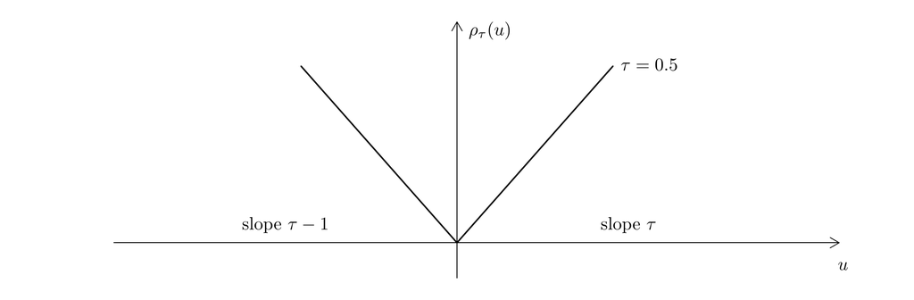

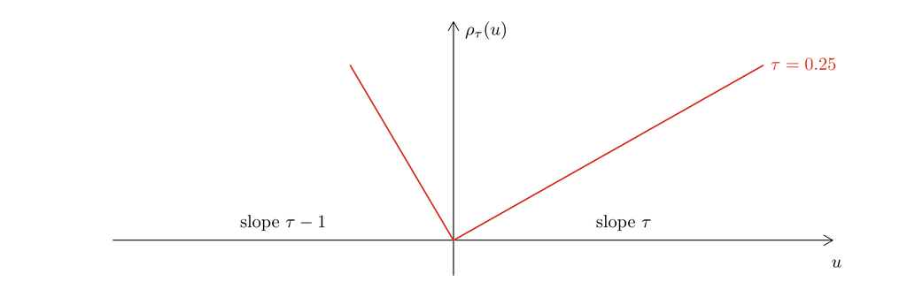

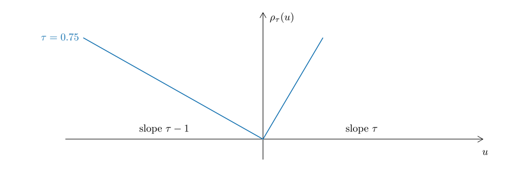

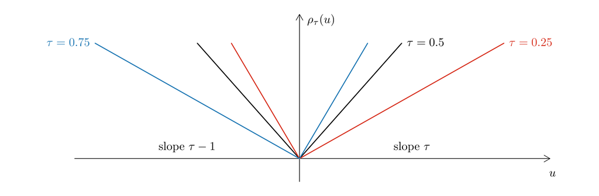

- $\tau < 0.5$: a check mark, $\checkmark$.

## Mean regression as a minimization

- $X_i$ now the $k \times 1$ vector of regressors, $\operatorname{rank}\left(\mathrm{E}\left[X_i X_i^\top\right]\right) = k$; $\beta, b \in \mathbb{R}^k$.
- Population, then sample:
  $$\begin{aligned}
  \mu = \mathrm{E}\left[Y_i\right] &= \underset{c \in \mathbb{R}}{\arg\min}\ \mathrm{E}\left[(Y_i - c)^2\right] \\
  \hat\mu &= \underset{c \in \mathbb{R}}{\arg\min}\ \frac{1}{n} \sum_{i=1}^n (Y_i - c)^2
  \end{aligned}$$
- Conditional mean:
  $$\mathrm{E}\left[Y_i \mid X_i\right] = \underset{c \in \mathbb{R}}{\arg\min}\ \mathrm{E}\left[(Y_i - c)^2 \mid X_i\right]$$
- Assume $\mathrm{E}\left[Y_i \mid X_i\right] = X_i^\top \beta$:
  $$\beta = \underset{b \in \mathbb{R}^k}{\arg\min}\ \mathrm{E}\left[(Y_i - X_i^\top b)^2\right]$$
- OLS:
  $$\hat\beta = \underset{b \in \mathbb{R}^k}{\arg\min}\ \frac{1}{n} \sum_{i=1}^n (Y_i - X_i^\top b)^2$$

## Quantile regression by analogy

- Population, then sample:
  $$\begin{aligned}
  q^Y_\tau &= \underset{c \in \mathbb{R}}{\arg\min}\ \mathrm{E}\left[\rho_\tau(Y_i - c)\right] \\
  \hat q^Y_\tau &= \underset{c \in \mathbb{R}}{\arg\min}\ \frac{1}{n} \sum_{i=1}^n \rho_\tau(Y_i - c)
  \end{aligned}$$
- Assume $q^Y_\tau(X_i) = X_i^\top \beta_\tau$:
  $$\beta_\tau = \underset{b \in \mathbb{R}^k}{\arg\min}\ \mathrm{E}\left[\rho_\tau(Y_i - X_i^\top b)\right]$$
- Quantile regression:
  $$\boxed{\ \hat\beta_\tau = \underset{b \in \mathbb{R}^k}{\arg\min}\ \frac{1}{n} \sum_{i=1}^n \rho_\tau(Y_i - X_i^\top b)\ }$$
- Estimated conditional quantile:
  $$\hat q^Y_\tau(X_i) = X_i^\top \hat\beta_\tau$$
- Koenker and Bassett (1978), Econometrica.

## Median regression

- Assume $q^Y_{0.5}(X_i) = X_i^\top \beta_{0.5}$:
  $$\beta_{0.5} = \underset{b \in \mathbb{R}^k}{\arg\min}\ \mathrm{E}\left[\rho_{0.5}(Y_i - X_i^\top b)\right]$$
- Estimator, with $\rho_{0.5}(u) = \tfrac12\, |u|$:
  $$\begin{aligned}
  \hat\beta_{0.5} &= \underset{b \in \mathbb{R}^k}{\arg\min}\ \frac{1}{n} \sum_{i=1}^n \rho_{0.5}(Y_i - X_i^\top b) \\
  &= \underset{b \in \mathbb{R}^k}{\arg\min}\ \frac{1}{n} \sum_{i=1}^n |Y_i - X_i^\top b|
  \end{aligned}$$
- Estimated conditional median:
  $$\hat q^Y_{0.5}(X_i) = X_i^\top \hat\beta_{0.5}$$

# Summary

## Effects at quantiles

- Normal, homoskedastic: $q^Y_\tau(X_i) = \beta_0 + \beta_1 X_i + \sigma z_\tau$; $\partial q^Y_\tau(X_i)/\partial X_i = \beta_1$ at every $\tau$, the same as at the mean.
- Normal, heteroskedastic: $q^Y_\tau(X_i) = \beta_0 + \beta_1 X_i + \sigma(X_i) z_\tau$; with $\sigma(X_i) = e^{\gamma_0 + \gamma_1 X_i}$, $\partial q^Y_\tau(X_i)/\partial X_i = \beta_1 + z_\tau \sigma(X_i) \gamma_1$.
- $\gamma_1 > 0$: effect above $\beta_1$ for $\tau > 0.5$, equal to $\beta_1$ at $\tau = 0.5$, below $\beta_1$ for $\tau < 0.5$.
- $U_i = \sigma(X_i)\,\varepsilon_i$, $\varepsilon_i \mid X_i \sim N(0,1)$; $\varepsilon_i = z_\tau \Longleftrightarrow Y_i = q^Y_\tau(X_i)$.

## Check function and quantile regression

- $\rho_\tau(u) = u\,(\tau - \mathbf{1}(u < 0))$, slope $\tau - 1$ for $u < 0$ and $\tau$ for $u > 0$; $\rho_{0.5}(u) = \tfrac12 |u|$.
- $\mu = \arg\min_c \mathrm{E}\left[(Y_i - c)^2\right]$ and $q^Y_\tau = \arg\min_c \mathrm{E}\left[\rho_\tau(Y_i - c)\right]$.
- $q^Y_\tau(X_i) = X_i^\top \beta_\tau$: $\hat\beta_\tau = \arg\min_b \frac{1}{n} \sum_{i=1}^n \rho_\tau(Y_i - X_i^\top b)$ and $\hat q^Y_\tau(X_i) = X_i^\top \hat\beta_\tau$; Koenker and Bassett (1978).
- $\tau = 0.5$: $\hat\beta_{0.5} = \arg\min_b \frac{1}{n} \sum_{i=1}^n |Y_i - X_i^\top b|$.